# Lab 3 - Tutorial

Nicholas N. Nagle

February 16, 2015

## Setup

First, let’s do some preliminary work: setting the workspace, loading libraries and loading data.

```r
setwd('~/Dropbox/git_root/homework/homework3/')
```

```r
library(ggplot2)
library(dplyr)
library(tidyr)
library(magrittr) # for the %$% notation I'll use later.
```

```r
precip <- read.csv('data/precip.csv')
rwi <- read.csv('data/rwi.csv')

summary(rwi)
```

```
##       year           rwi           samp.depth
##  Min.   :-136   Min.   :-0.033   Min.   : 1.0
##  1st Qu.: 399   1st Qu.: 0.661   1st Qu.: 8.0
##  Median : 934   Median : 0.966   Median :13.0
##  Mean   : 934   Mean   : 0.977   Mean   :16.4
##  3rd Qu.:1469   3rd Qu.: 1.259   3rd Qu.:23.0
##  Max.   :2004   Max.   : 3.064   Max.   :66.0
```

```r
summary(precip)
```

```
##       year           Jan             Feb             Mar
##  Min.   :1895   Min.   :0.020   Min.   :0.030   Min.   :0.020
##  1st Qu.:1925   1st Qu.:0.335   1st Qu.:0.350   1st Qu.:0.448
##  Median :1954   Median :0.710   Median :0.680   Median :0.695
##  Mean   :1954   Mean   :0.837   Mean   :0.834   Mean   :0.864
##  3rd Qu.:1984   3rd Qu.:1.198   3rd Qu.:1.157   3rd Qu.:1.242
##  Max.   :2014   Max.   :2.790   Max.   :3.310   Max.   :3.180
##       Apr             May             Jun             Jul
##  Min.   :0.010   Min.   :0.000   Min.   :0.000   Min.   :0.86
##  1st Qu.:0.228   1st Qu.:0.150   1st Qu.:0.245   1st Qu.:1.88
##  Median :0.500   Median :0.360   Median :0.605   Median :2.56
##  Mean   :0.653   Mean   :0.544   Mean   :0.713   Mean   :2.66
##  3rd Qu.:0.873   3rd Qu.:0.802   3rd Qu.:1.093   3rd Qu.:3.29
##  Max.   :2.980   Max.   :3.010   Max.   :2.500   Max.   :5.96
##       Aug            Sep            Oct             Nov
##  Min.   :0.60   Min.   :0.03   Min.   :0.000   Min.   :0.000
##  1st Qu.:2.25   1st Qu.:1.06   1st Qu.:0.388   1st Qu.:0.205
##  Median :2.81   Median :1.77   Median :0.890   Median :0.590
##  Mean   :2.86   Mean   :1.82   Mean   :1.147   Mean   :0.725
##  3rd Qu.:3.39   3rd Qu.:2.43   3rd Qu.:1.653   3rd Qu.:0.970
##  Max.   :5.82   Max.   :5.11   Max.   :5.180   Max.   :4.030
##       Dec
##  Min.   :-9.990
##  1st Qu.: 0.368
##  Median : 0.780
##  Mean   : 0.916
##  3rd Qu.: 1.460
##  Max.   : 3.920
```

## Data Tidying

I want to create a data.frame that has columns of:

year, month, precip. Remember, the precip does not come in that format. Instead it looks like this:

```r
head(precip)
```

```
##   year  Jan  Feb  Mar  Apr  May  Jun  Jul  Aug  Sep  Oct  Nov  Dec
## 1 1895 1.08 0.78 0.11 0.10 1.12 0.63 4.07 3.74 1.25 0.81 1.73 0.23
## 2 1896 0.25 0.20 0.20 0.15 0.01 0.71 3.25 1.80 2.37 4.28 0.10 0.22
## 3 1897 1.29 0.20 1.15 0.69 1.09 0.56 2.57 2.57 4.77 1.99 0.08 0.69
## 4 1898 1.13 0.35 0.98 0.88 0.31 1.89 3.49 2.87 0.66 0.05 0.93 1.19
## 5 1899 0.22 0.21 0.43 0.55 0.03 0.78 3.91 1.43 1.17 0.47 0.50 0.24
## 6 1900 0.69 0.50 1.08 0.94 0.36 0.23 1.18 0.94 3.53 0.43 0.75 0.28
```

I will gather the data into one column called precip…

```r
precip.df <- precip %>% gather(key=month, value=precip, -year) %>% arrange(year, month)
head(precip.df)
```

```
##   year month precip
## 1 1895   Jan   1.08
## 2 1895   Feb   0.78
## 3 1895   Mar   0.11
## 4 1895   Apr   0.10
## 5 1895   May   1.12
## 6 1895   Jun   0.63
```

We are going to create a new column that is the “hydologic year”, or the precipitation year that the tree growth seems to correspond to. In the previous lab we looked at correlations between tree ring width and monthly precipitation. It seemed that tree ring width is most correlated with precipitation from the previous July to the current June.

To create the “hydrologic year”“, we will shift the year column forward by 6 months, so that the new year starts in July rather than next January. We’ll use the ‘lead’ function in the dplyr package.

```r
precip.df <- precip.df %>% mutate(water_year = lead(year, 6))
head(precip.df, 20)
```

```
##    year month precip water_year
## 1  1895   Jan   1.08       1895
## 2  1895   Feb   0.78       1895
## 3  1895   Mar   0.11       1895
## 4  1895   Apr   0.10       1895
## 5  1895   May   1.12       1895
## 6  1895   Jun   0.63       1895
## 7  1895   Jul   4.07       1896
## 8  1895   Aug   3.74       1896
## 9  1895   Sep   1.25       1896
## 10 1895   Oct   0.81       1896
## 11 1895   Nov   1.73       1896
## 12 1895   Dec   0.23       1896
## 13 1896   Jan   0.25       1896
## 14 1896   Feb   0.20       1896
## 15 1896   Mar   0.20       1896
## 16 1896   Apr   0.15       1896
## 17 1896   May   0.01       1896
## 18 1896   Jun   0.71       1896
## 19 1896   Jul   3.25       1897
## 20 1896   Aug   1.80       1897
```

With this water_year column in place, we want to calculate the total precipitation each water_year. This is a group and summarize task.

```r
annual_precip <- precip.df %>% group_by(water_year) %>%
  summarize(precip=sum(precip)) %>%
  filter(water_year>1895)
# Don't forget to filter out year=1895 because it wasn't complete.
head(annual_precip)
```

```
## Source: local data frame [6 x 2]
##
##   water_year precip
## 1       1896  13.35
## 2       1897  17.00
## 3       1898  18.21
## 4       1899  11.41
## 5       1900  11.52
## 6       1901  10.43
```

Now we can merge that with the tree ring data…

```r
rwi.precip.df <- left_join(rwi, annual_precip, by=c('year'='water_year'))
tail(rwi.precip.df)
```

```
##      year    rwi samp.depth precip
## 2136 1999  1.157         60  14.93
## 2137 2000  0.591         60  15.75
## 2138 2001  0.913         60  15.48
## 2139 2002 -0.033         59   9.77
## 2140 2003  0.710         59  15.02
## 2141 2004  0.419         53  12.87
```

## Exploratory analysis

Plot a scatterplot. You should always visualize the data first.

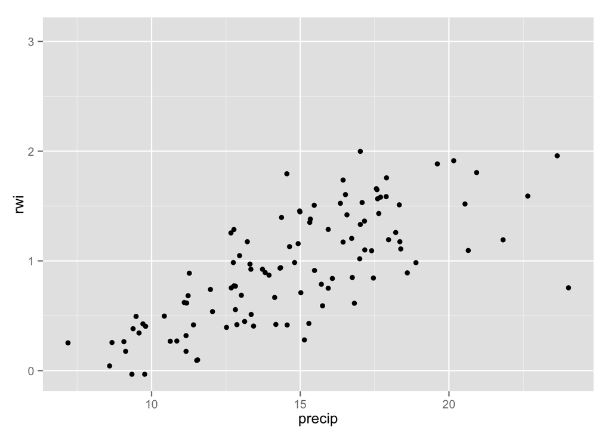

```r
ggplot(data=rwi.precip.df) + geom_point(aes(x=precip, y=rwi))
```

There is clearly a positive relationship between annual precipitation and ring width. There is a possibility of nonlinear relationship; it appears that there are “diminishing returns” to precipitation. A little precipitation is good for trees, but eventually an increase in rain does not lead to any extra increase in tree growth.

## Linear regression

Nonetheless, we’ll fit a linear regression to the data.

```r
# Fit the model
model <- lm(rwi~precip, data=rwi.precip.df)
# Print out a summary
summary(model)
```

```
##
## Call:
## lm(formula = rwi ~ precip, data = rwi.precip.df)
##
## Residuals:
##     Min      1Q  Median      3Q     Max
## -1.1896 -0.2434  0.0335  0.2188  0.8765
##
## Coefficients:
##             Estimate Std. Error t value Pr(>|t|)
## (Intercept) -0.66062    0.14658   -4.51  1.7e-05 ***
## precip       0.10846    0.00968   11.20  < 2e-16 ***
## ---
## Signif. codes:  0 '***' 0.001 '**' 0.01 '*' 0.05 '.' 0.1 ' ' 1
##
## Residual standard error: 0.348 on 107 degrees of freedom
##   (2032 observations deleted due to missingness)
## Multiple R-squared:  0.54,   Adjusted R-squared:  0.535
## F-statistic:  125 on 1 and 107 DF,  p-value: <2e-16
```

We also see the $R^2$ of 0.5397.

## Regression Diagnostics

Regression is easy enough. We can always run a regression and get results. But should we? Should we run the regression? Should we trust the results? For this, we need to qualitatively evaluate the assumptions. This is mixture of knowing your data, knowing your science, looking at a few different types of plots, and a little creativity. What’s worse, is that it’s a lot of work, and it’s never going to get published. It is just assumed that the regression is OK, and if a reviewer questions you on the regression, you should have the supporting evidence that you will need already.

Here is a quick way to do the regression diagnostic plots.

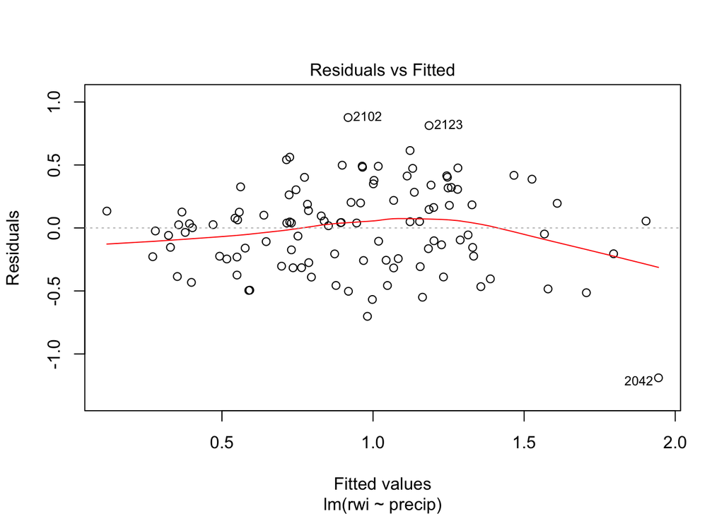

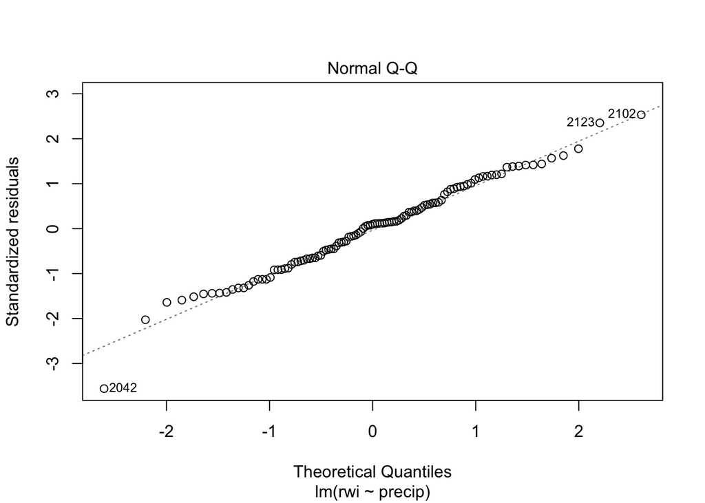

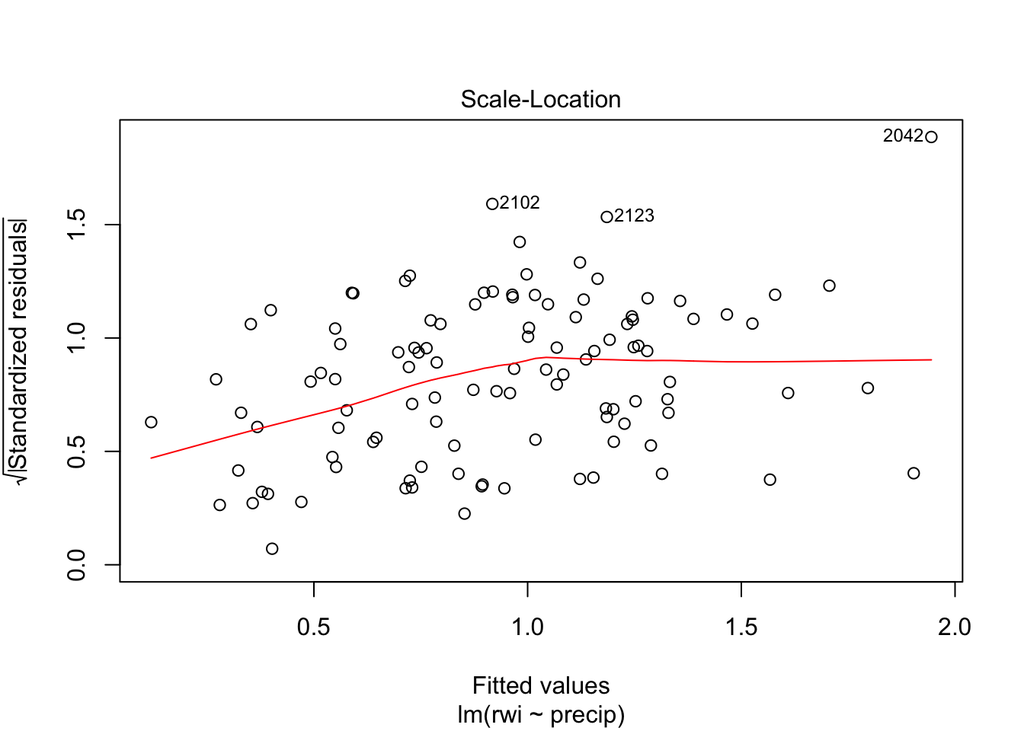

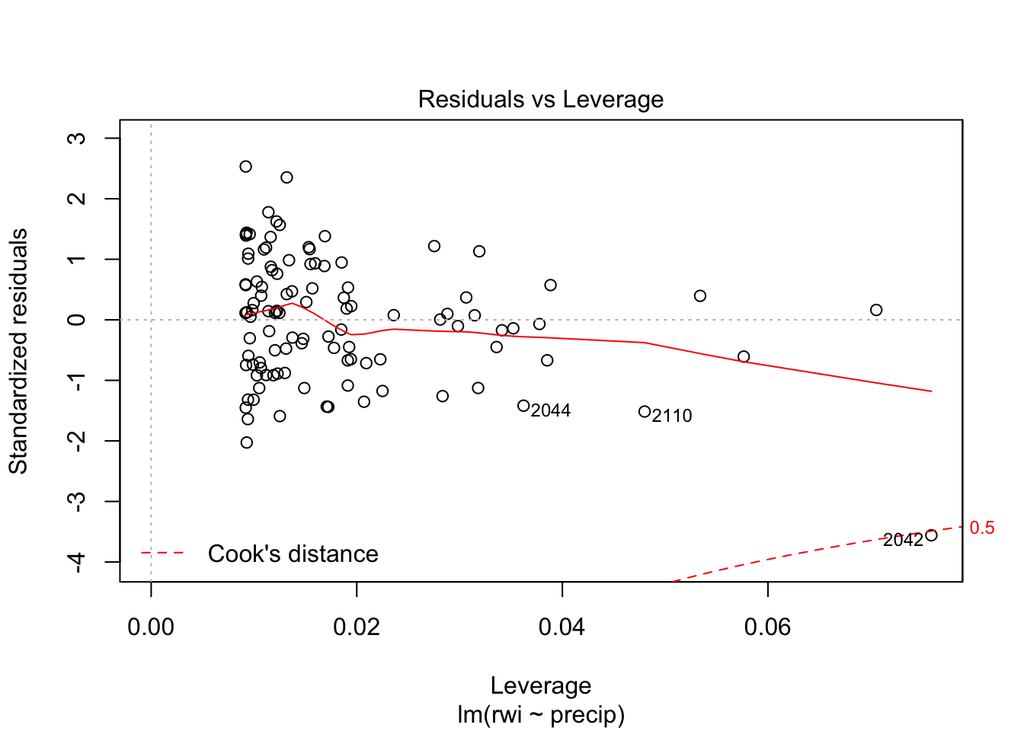

```r
plot(model) # You can then step through each plot, Hit <Return> to see the next plot
```

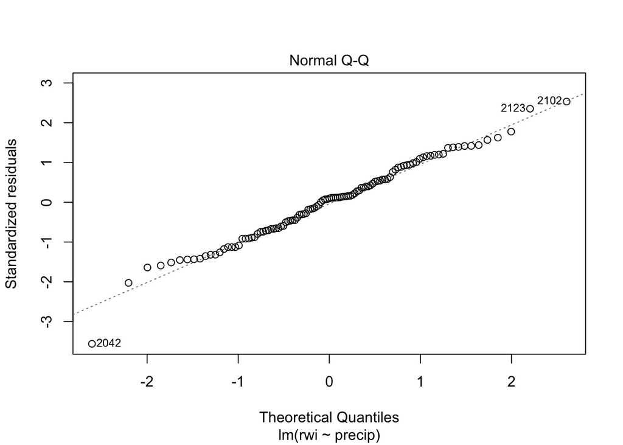

```r
# Or you can see one plot at a time, e.g.
plot(model, which=2)
```

First, a little about residuals. First of all, regression residuals are not population model errors. The residuals are #estimates# of the population errors. Not all regression residuals are created equal. Some data rows have residuals that are noisier than other rows. In particular, the estimated residuals at the left and right are not as accurate as the estimated residuals near thecenter. Even if the data have constant variance, the regression residuals do not. The ‘standardized residuals’ correct for this. There is also something called ‘studentized residuals’. There is usually very little difference in practice, but the studentized residuals may be more robust to outliers.

Homework: For the first three plots, describe wich assumptions they help to visually evaluate.

There appears to be a slight nonlinearity in the dataset. We noted this in the initial scatterplot. As you move from low to high fitted values, the residuals tend to be low, then high, then low again. It’s hard to tell how much of a problem this is, and how to fix it. Possible technical solutions might be:

1. log or square root transforming the predictand and/or predictor variables. Transforming the dependent variable is not a problem for the regression, but it does complicate how we interpret the prediction.
2. Adding precipitation squared as a predictor variable (this is a multivariate regression, we’ll cover that in class soon)
3. Nonlinear regression (I won’t cover this in lab)

For these particular data, my hunch is that precipitation has diminishing returns to tree growth. I would probably try a log transformation of the data first.

Here is a regression with just the subset with precip less than 20. The nonlinearity looks like it has been removed.

```r
# Fit the model
model2 <- lm((rwi)~(precip), data=rwi.precip.df, subset=(precip<20))
# Print out a summary
summary(model2)
```

```
##
## Call:
## lm(formula = (rwi) ~ (precip), data = rwi.precip.df, subset = (precip <
##     20))
##
## Residuals:
##    Min     1Q Median     3Q    Max
## -0.738 -0.255  0.045  0.218  0.852
##
## Coefficients:
##             Estimate Std. Error t value Pr(>|t|)
## (Intercept)  -0.9224     0.1617    -5.7  1.2e-07 ***
## precip        0.1282     0.0112    11.5  < 2e-16 ***
## ---
## Signif. codes:  0 '***' 0.001 '**' 0.01 '*' 0.05 '.' 0.1 ' ' 1
##
## Residual standard error: 0.325 on 99 degrees of freedom
##   (2032 observations deleted due to missingness)
## Multiple R-squared:  0.571,  Adjusted R-squared:  0.567
## F-statistic:  132 on 1 and 99 DF,  p-value: <2e-16
```

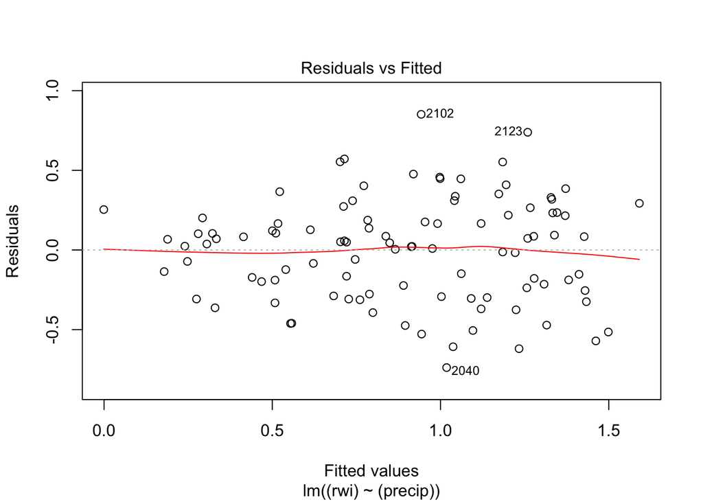

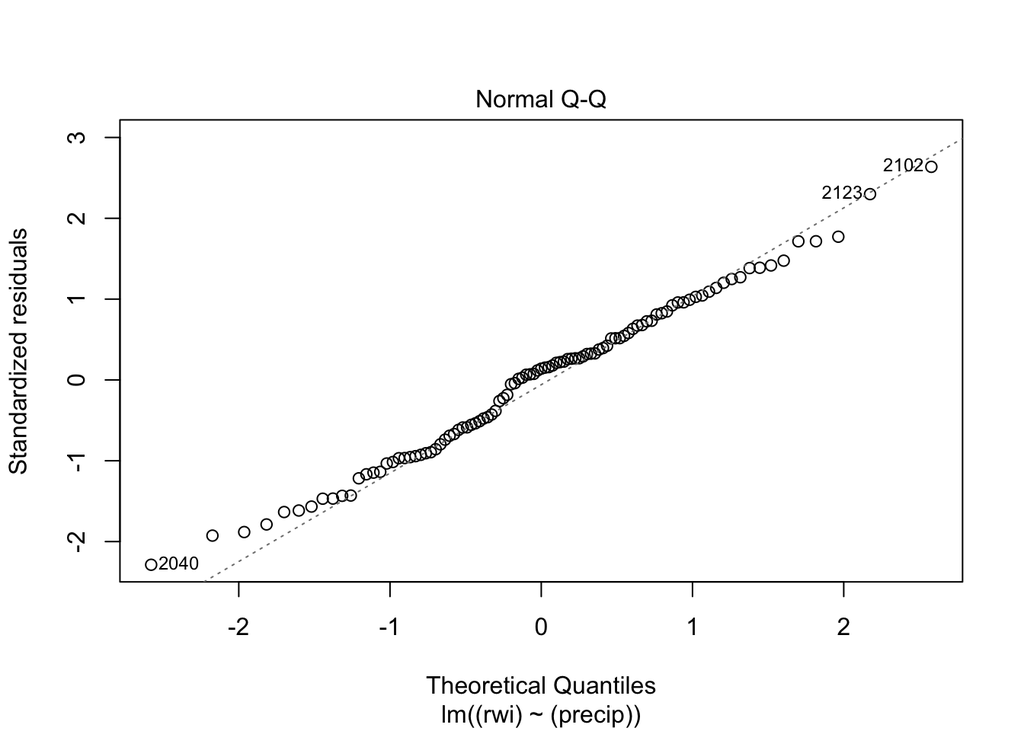

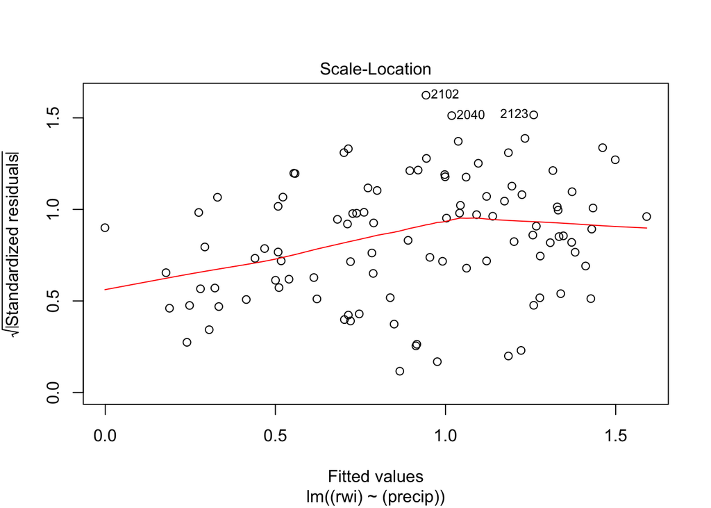

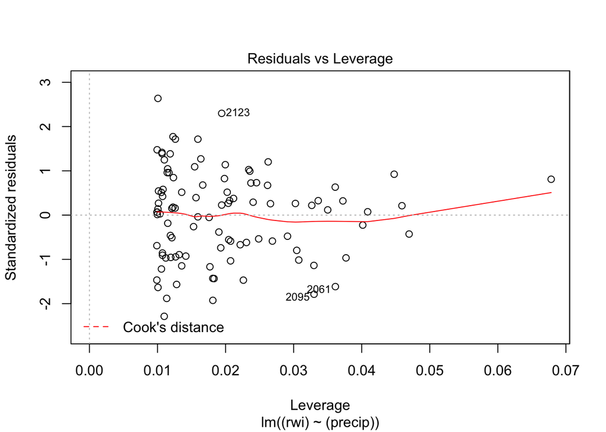

```r
plot(model2)
```